# **maftools package in R**

[figure not shown]

## required **Mutation Annotation Format (MAF)** file

### Masked Somatic Mutation analysis

`maftools` provides various functions to perform most commonly used analyses in cancer genomics. This package attempts to summarize, analyze, annotate and visualize MAF files in an efficient manner from either **The Cancer Genome Atlas (TCGA)** sources or any in-house studies as long as the data is in **MAF** format.

[DOI:10.18129/B9.bioc.maftools](https://www.bioconductor.org/packages/release/bioc/html/maftools.html)

Such cohort-based large-scale characterizations often produce large amounts of data in the form of *somatic variants* containing **single-nucleotide variants (SNV)** and small insertion/deletions (indels). Somatic variants provide baseline data for many analyses, such as **Single Nucleotide Polimorphism (SNP)** types, driver gene detection, mutation frequencies, somatic interactions, visualization, and estimation of tumor heterogeneity, applied by the package employment.

Thanks to [Genome Resarch. PMID: 30341162](https://doi.org/10.1101/gr.239244.118) and PoisonAlien/maftools

### Installation

Install from `BiocManager` package

`{r} BiocManager::install("maftools")`

`{r} library(maftools)`

##### **Required files**

- MAF files - can be obtained from TCGA or gz compressed.
- here we downloaded the MAF file of LUAD cohort from TCGA (GDC portal)

`{r} library(TCGAbiolinks)`

`{r} library(DT)`

`{r} library(dplyr)`

`{r} luad_maf <- GDCquery(project = "TCGA-LUAD", data.category = "Simple Nucleotide Variation", data.type = "Masked Somatic Mutation", access = "open")`

`{r} GDCdownload(luad_maf,method = "client")`

`{r} luadmaf <- GDCprepare(luad_maf)`

Now, we have all genes with mutation types in LUAD cohort along with features data. SNP mutations are detectable in the output table, which can be separated based on *Variant_Classification* column in *luadmaf* table resulted from `GDCprepare` function.

`{r} head (luadmaf)`

```
A tibble: 6 × 140
  Hugo_Symbol Entrez_Gene_Id Center NCBI_Build Chromosome Start_Position End_Position Strand Variant_Classification
  <chr>                <int> <chr>  <chr>      <chr>               <int>        <int> <chr>  <chr>
1 ELAPOR1              57535 BI     GRCh38     chr1            109197542    109197542 +      Silent
2 HIPK1               204851 BI     GRCh38     chr1            113962403    113962403 +      Missense_Mutation
3 FDPS                  2224 BI     GRCh38     chr1            155319833    155319833 +      Missense_Mutation
4 YY1AP1               55249 BI     GRCh38     chr1            155668660    155668660 +      Silent
5 FCRL3               115352 BI     GRCh38     chr1            157697402    157697402 +      Silent
6 OR6F1               343169 BI     GRCh38     chr1            247712205    247712205 +      Missense_Mutation
```

We also access to altered alleles and substitutions’ position in each gene, indication nucleotides and amino acid exchanges in columns: *HGVSc*, *HGVSp*, and *HGVSp_Short*.

```
 HGVSc     HGVSp       HGVSp_Short
  <chr>     <chr>       <chr>
1 c.2190C>T p.Phe730=   p.F730=
2 c.2068C>G p.Gln690Glu p.Q690E
3 c.964G>C  p.Gly322Arg p.G322R
4 c.984C>T  p.Leu328=   p.L328=
5 c.582G>T  p.Leu194=   p.L194=
6 c.551G>T  p.Trp184Leu p.W184L
```

##### **Reading MAF file**

- `read.maf` function reads and summarizes MAF files in various ways, and stores as a MAF object.
- It is recommended to provide annotations associated with samples in MAF.
- Here I read MAF file of LUAD cohort based on an object resulted from `GDCprepare` function because there are sample barcodes annotation in it.

`{r} LUAD <- read.maf(maf = luadmaf)`

```
#Validating
-Silent variants: 47915
-Summarizing
--Possible FLAGS among top ten genes:
  TTN
  MUC16
  USH2A
  FLG
-Processing clinical data
-Processing clinical data
-Finished in 30.9s elapsed (25.6s cpu)
```

```
#Typing laml shows basic summary of MAF file.

LUAD
```

```
An object of class  MAF
                        ID summary    Mean Median
                    <char>  <char>   <num>  <num>
 1:             NCBI_Build  GRCh38      NA     NA
 2:                 Center      BI      NA     NA
 3:                Samples     616      NA     NA
 4:                 nGenes   16642      NA     NA
 5:        Frame_Shift_Del    4256   6.909    4.0
 6:        Frame_Shift_Ins    1290   2.094    1.0
 7:           In_Frame_Del     406   0.659    0.0
 8:           In_Frame_Ins      49   0.080    0.0
 9:      Missense_Mutation  126254 204.958  137.5
10:      Nonsense_Mutation   10454  16.971   10.0
11:       Nonstop_Mutation     175   0.284    0.0
12:            Splice_Site    3719   6.037    3.0
13: Translation_Start_Site     211   0.343    0.0
14:                  total  146814 238.334  158.5
```

> sample summary

`{r} sample <- getSampleSummary(LUAD)`

> Gene summary

`{r} gene <- getGeneSummary(LUAD)`

> Recommended clinical data associated with each sample/Tumor_Sample_Barcode in MAF.
- Here I get the linicalData from MAF file resulted from `read.maf` function. Another way is to obtain clinical data frame from GDC portal using `GDCquery` function.

`{r} clin <- getClinicalData(LUAD)`

### **Analysis**

#### Somatic Interactions

Interaction between pair genes using `somaticInteractions` function based on:

- **Co-occurance**- co-occurance frequency - both genes are often mutated together.
- **Mutually exlusive** - One gene is mutated, the other gene is not.

Useful for identification of relationships between genes based on their mutation patterns across a population of samples. Highlights potential functional connections between the genes.

- Significance customization – *P.Value < 0.05 or 0.01*

`{r} somaticinter <- somaticInteractions(maf = LUAD, top = 20, pvalue = 0.01)`

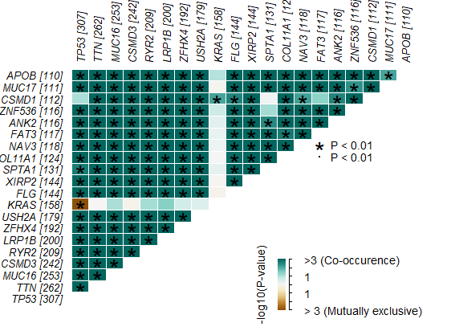

[figure not shown]

Binary feature for identifying mutated or non-mutated based on *0* and *1*

The result shows pair genes interacted together. The significant interactions are identified by *pAdj* column and the interaction type is described by *Event* column.

```
gene1  gene2       pValue oddsRatio    00    01    11    10         pAdj        Event         pair
   <char> <char>        <num>     <num> <int> <int> <int> <int>        <num>       <char>       <char>
1:  LRP1B  MUC16 1.122434e-18  4.882350   296   120   133    67 2.040789e-17 Co_Occurence LRP1B, MUC16
2:  CSMD3    TTN 3.465805e-18  4.433788   267   107   155    87 5.776341e-17 Co_Occurence   CSMD3, TTN
3:  USH2A  CSMD3 1.326806e-17  4.868679   313   124   118    61 2.041241e-16 Co_Occurence CSMD3, USH2A
4:    TTN  MUC16 6.281772e-17  4.131432   259    95   158   104 8.973961e-16 Co_Occurence   MUC16, TTN
5:   APOB  MUC16 1.693377e-16  6.421572   337   169    84    26 2.257836e-15 Co_Occurence  APOB, MUC16
6:    TTN  USH2A 1.019462e-15  4.367813   296    58   121   141 1.274328e-14 Co_Occurence   TTN, USH2A
```

#### Detecting driver genes

`maftools` has a function `oncodrive` which identifies cancer genes (driver) from a given MAF. *Oncodriver* - driver genes - Concept is based on the fact that most of the variants in cancer causing genes are enriched at *few specific loci* (hot-spots).

`{r} driver <- oncodrive(maf = LUAD, minMut = 5, pvalMethod = "zscore")`

```
Estimating background scores from synonymous variants..
Assuming protein change information are stored under column HGVSp_Short. Use argument AACol to override if necessary.
```

```
 Hugo_Symbol Frame_Shift_Del Frame_Shift_Ins In_Frame_Del In_Frame_Ins Missense_Mutation
        <char>           <int>           <int>        <int>        <int>             <int>
1:    CDC42EP2               0               0            0            0                 5
2:       DDX49               0               0            0            0                 8
3:     DEFB121               0               0            0            0                 6
4:     KRTCAP3               0               0            0            0                 6
5:        LCAT               0               0            0            0                 4
6:         OXT               0               0            0            0                 6
   Nonsense_Mutation Nonstop_Mutation Splice_Site Translation_Start_Site total MutatedSamples
               <int>            <int>       <int>                  <int> <num>          <int>
1:                 0                0           0                      0     5              5
2:                 0                0           0                      0     8              8
3:                 0                0           0                      0     6              6
4:                 0                0           0                      0     6              6
5:                 1                0           0                      0     5              4
```

[output cut: 17 more lines]

#### Protein domain changes

`maftools` comes with the function `pfamDomains`, which adds **pfam** domain information to the *amino acid changes*. Adding pfam domain changes for detection of amino acid changes in protein.`pfamDomain` also summarizes amino acid changes according to the domains that are affected.

`{r} pfam <- pfamDomains(maf = LUAD, top = 10)`

Get summary of protein and amino acid

`{r} prSum <- pfam$proteinSummary Dsum <- pfam$domainSummary`

`{r} head(prSum)`

```
    HGNC AAPos Variant_Classification     N total  fraction DomainLabel       pfam
    <char> <num>                 <fctr> <int> <num>     <num>      <char>     <char>
1:    KRAS    12      Missense_Mutation   146   163 0.8957055     COG1100       <NA>
2:    EGFR   858      Missense_Mutation    23   104 0.2211538   PTKc_EGFR    cd05108
3:    EGFR   746           In_Frame_Del    21   104 0.2019231   PTKc_EGFR    cd05108
4:    BRAF   640      Missense_Mutation    13    54 0.2407407     Pkinase  pfam00069
5: ALDH1B1    75      Missense_Mutation    12    22 0.5454545    PLN02466       <NA>
6:   CD163   987      Missense_Mutation    12    52 0.2307692          SR smart00202
                                                                         Description
                                                                              <char>
1:       GTPase SAR1 and related small G proteins [General function prediction only]
2: Catalytic domain of the Protein Tyrosine Kinase, Epidermal Growth Factor Receptor
3: Catalytic domain of the Protein Tyrosine Kinase, Epidermal Growth Factor Receptor
4:                                                             Protein kinase domain
5:                                            aldehyde dehydrogenase family 2 member
6:                                                       Scavenger receptor Cys-rich
```

#### Survival

##### Survival analysis - Kaplan_miere (KM)

> Survival analysis is an essential part of cohort anaysis.

Required clinical input => Tumor_sample_Barcode -> matches to those in MAF file.

binary event -> 1,0 => Status (vital_status): Alive = 0, Dead = 1

time to event -> last followup => days

We can load clinical data in various ways such as TCGA or othe clinical files including annotation of samples, specifically **Tumor_sample_Barcode** column as in MAF file.

- Here I load all data of LUAD combined with clinical data

`{r} cohort <- tcgaLoad(study = "LUAD")`

releasing clinicalData

`{r} clin <- getClinicalData(cohort)`

removing *NA* values and setting *0* and *1* for *Alive* and *DEAD* status respectively because it is important to have binary feature.

`{r} clin$days_to_last_followup[clin$days_to_last_followup=="[Not Available]"] <- NA clin$vital_status[clin$vital_status=="Alive"] <- 0 clin$vital_status[clin$vital_status=="Dead"] <- 1`

obtaining all data

`{r} data <- cohort@data`

`{r} luad <- read.maf(data, clinicalData = clin)`

Now, we have a full data with clinical eature added.

Function `mafSurvive` performs survival analysis and draws kaplan meier curve by grouping samples based on mutation status

`{r} mafSurvival(maf = luad, genes = "DNMT3A", time = "days_to_last_followup", Status = "vital_status")`

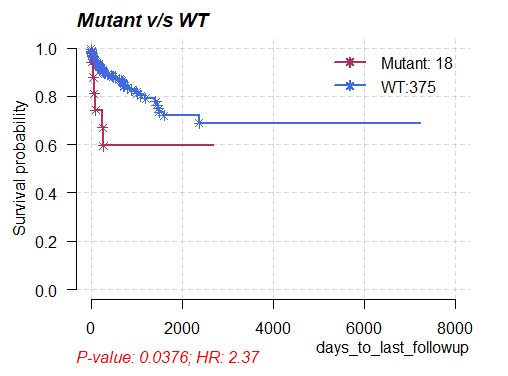

```
   Group   medianTime   N
   <char>      <num> <int>
1: Mutant      259.5    18
2:     WT      626.0   375
```

## Visualization

- Summary of variant classification

`{r} plotmafSummary(maf = luad, rmOutlier = T, addStat = "median", dashboard = T, titvRaw = F)`

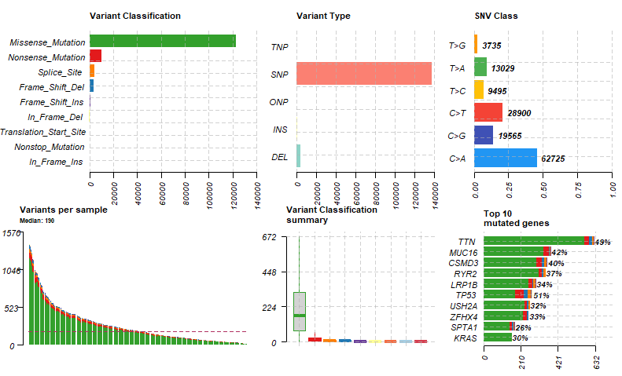

- Oncoplot

`{r} oncoplot(maf = luad)`

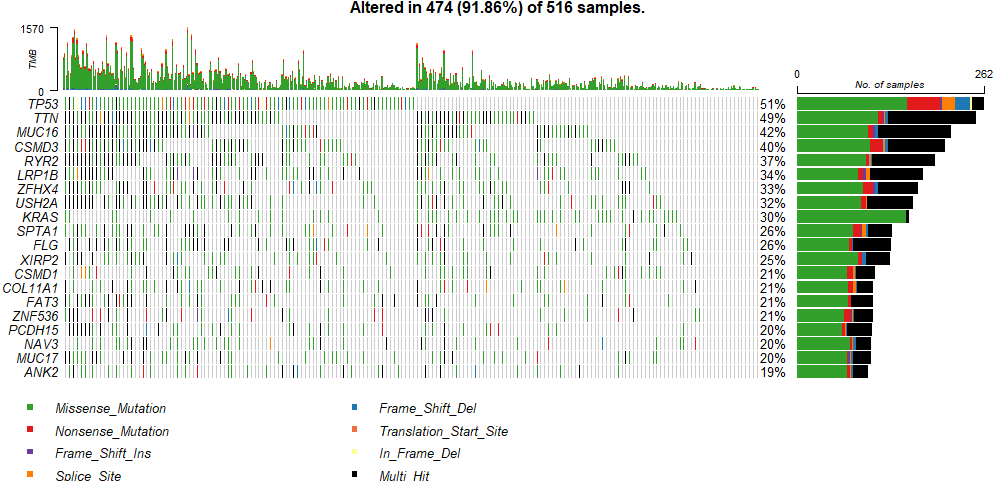

- Transition and Transversion

`{r} luad.titv <- titv(maf = luad,plot = F, useSyn = T)`

- Lollipop plot